# Coding as a Service: Librería pypsdier, aprendizajes y metodología.

## Sebastián Flores

### Pycon Argentina 2020

[figure not shown]

##### Coding as a Service: librería pypsdier, aprendizajes y metodología.

### Observaciones:

- @sebastiandres en twitter y github.
- Opiniones y críticas a título personal.
- No se necesita conocer de química, matemática o python avanzado.
- Presentación disponible en https://www.github.com/sebastiandres/charlas y realizada con jupyter+RISE.

##### Coding as a Service: librería pypsdier, aprendizajes y metodología.

### Autores

[figure not shown]

#### Sebastián Flores

M.Sc. Mathematical and Computational Engineering  
M.Sc. Mécanique Numérique  
Ingeniero Civil Matemático  
u-planner - Chile

[figure not shown]

#### Pedro Valencia

Ph.D Ingeniería Bioquímica  
M.Sc. Ingeniería Bioquímica  
Bioquímico  
UTFSM - Chile

##### Coding as a Service: librería pypsdier, aprendizajes y metodología

### Historia

- Origen:
  - Proyecto de colaboración en curso de matemáticas aplicadas.
- Primeras implementaciones en MATLAB:
  - Problema: Cada nueva reacción química requiere una nueva implementación numérica.
  - Repetición de código y mantención tediosa.
- Desarrollo en Python:
  - Código genérico: librería pypsdier.
  - Interface simple e instalación por pypi.
  - Reacciones químicas definidas como funciones.
  - Número arbitrario de sustancias (sustratos o productos).
  - Tamaño de partículas definidas por una lista de radios y frecuencias.
- Impacto:
  - 9 publicaciones.
  - Código abierto y en constante evolución.

##### Coding as a Service: librería pypsdier, aprendizajes y metodología

### Problema

- Pedro no conocía Python. Actualmente, nivel de usuario básico.
- Sebastián tiene (aún) conocimientos nulos en bioquímica.

**¿Cómo colaborar de manera eficiente?**

El problema más general:

**¿Cuál es la manera más sencilla de entregar "Coding As A Service"?**

##### Coding as a Service: librería pypsdier, aprendizajes y metodología

### Ejemplo

¿Cuál es la manera más sencilla de entregar "Coding As A Service"?

Tiene que ser tan fácil que puedas explicárselo a tu abuela.

[figure not shown]

##### Coding as a Service: librería pypsdier, aprendizajes y metodología

### Solución para la abuela

Abue, vaya a este link y aprete play:

https://bit.ly/2IetMRn

##### Coding as a Service: librería pypsdier, aprendizajes y metodología.

### Nuestro problema a resolver

[figure not shown]

##### Coding as a Service: librería pypsdier, aprendizajes y metodología.

### Nuestro problema a resolver

[figure not shown]

##### Coding as a Service: librería pypsdier, aprendizajes y metodología.

### Nuestro problema a resolver

El problema es obtener $S_b(t)$ y $S(t,r,R_i)$, para $t>0$, $0<r<R_i$.

$$ \frac{\partial S}{\partial t}(t,r,R_i) = D_S \left(\frac{\partial^2 S}{\partial r^2}(t,r,R_i) + \frac{2}{r}\frac{\partial S}{\partial r}(t,r,R_i)\right) - V_e\left(S, r, t \right) $$

Condición de borde en el centro de las partículas:

\begin{align} \frac{\partial S}{\partial r}(t, 0, R_i) = 0 \textrm{ para } t > 0 \end{align}

Condiciones de borde en la superficie de la partícula:

\begin{align} S_b(t) = S(t, R_i,R_i) \textrm{ para } t > 0 \end{align}\begin{align} \frac{d S_b}{d t}(t) &= - 3 D_S \frac{V_c}{V_R E \left[ R^3 \right] } E \left[ R^2 \left. \frac{\partial S}{\partial r} \right|_{r=R} \right] \textrm{ para } t > 0 \end{align}

Con la condición inicial

\begin{align} S_b(0) &= S_0 \\ S(0,r, R_i) &= 0 \textrm{ para } 0 \leq r < R_i \end{align}

##### Coding as a Service: librería pypsdier, aprendizajes y metodología.

### Nuestro problema a resolver

[figure not shown]

##### Coding as a Service: librería pypsdier, aprendizajes y metodología.

### Los Desafíos

Desafíos técnicos:

- ¿Cómo discretizar las ecuaciones?
- ¿Cómo realizar la implementación numérica?
- ¿Cómo resolver para reacciones químicas distintas y un número arbitrario de sustancias y tamaños de partículas?

Esta es la parte tiene solución directa y conocida:

- Discretizar ecuaciones utilizando diferencias finitas para el tiempo ($\Delta t$) y espacio ($\Delta R_i$).
- Asegurar estabilidad numérica dependiendo de los inputs.
- Implementación flexible con python + numpy + matplotlib + otros.

##### Coding as a Service: librería pypsdier, aprendizajes y metodología.

### Los Desafíos

Desafíos organizacionales:

- ¿Cómo colaborar?
- ¿Cómo distribuir el código?
- ¿Cómo hacer fácil el uso?
- ¿Cómo hacer reproducible las simulaciones?
- ¿Cómo documentar el código?
- ¿Cómo almacenar los resultados de las simulaciones?

Esta parte no tiene una solución directa:

- No había mucha información al respecto.
- Cada equipo lo resuelve a su manera.
- Existen muchas herramientas que nos simplifican la vida.

##### Coding as a Service: librería pypsdier, aprendizajes y metodología

### Framework: ¿Qué necesitábamos?

(1) Propocionar **instalación** y **versionamiento** de python, jupyter y librerías necesarias.

(2) Facilitar **desarrollo incremental** considerando devs y users.

(3) Permitir una buena **documentación** para desarrolladores y usuarios.

(4) Exponer una **interface simple** al usuario final, permitiendo ocultar una implementación numérica compleja y con una curva de aprendizaje apropiado.

(5) Permitir **reproducir**, **almacenar** y **compartir** resultados de simulación.

(6) Permitir el uso de recursos computacionales en la **nube**.

##### Coding as a Service: librería pypsdier, aprendizajes y metodología

#### Necesidades

(1) Propocionar **instalación** y **versionamiento** de python, jupyter y librerías necesarias.

(2) Facilitar **desarrollo incremental** considerando desarrolladores y usuarios.

### Solución

Estructura de proyecto de python, para instalar con pypi o desde github.

[figure not shown]

##### Coding as a Service: librería pypsdier, aprendizajes y metodología

#### Necesidades

(3) Permitir una buena **documentación** para desarrolladores y usuarios.

### Solución

[figure not shown]

##### Coding as a Service: librería pypsdier, aprendizajes y metodología

#### Necesidades

(4) Exponer una **interface simple** al usuario final, permitiendo ocultar una implementación numérica compleja y con una curva de aprendizaje apropiado.

(5) Permitir **reproducir**, **almacenar** y **compartir** resultados de simulación.

### Solución

[figure not shown]

##### Coding as a Service: librería pypsdier, aprendizajes y metodología

### Solución

(5) Permitir **reproducir**, **almacenar** y **compartir** resultados de simulación.

(6) Permitir el uso de recursos computacionales en la **nube**.

### Solución

[figure not shown]

##### Coding as a Service: librería pypsdier, aprendizajes y metodología

### Ejemplo de pypsdier

Primero que nada, instalaremos la librería:

```python
#!pip install pypsdier --upgrade
!pip install git+https://github.com/sebastiandres/pypsdier.git --upgrade
```

```
  Cloning https://github.com/sebastiandres/pypsdier.git to /private/var/folders/68/v1ds0ld152q_wk4sbcns3ckw0000gn/T/pip-req-build-mm52_b8o
  Running command git clone -q https://github.com/sebastiandres/pypsdier.git /private/var/folders/68/v1ds0ld152q_wk4sbcns3ckw0000gn/T/pip-req-build-mm52_b8o
  Found existing installation: pypsdier 1.1.1
    Uninstalling pypsdier-1.1.1:
      Successfully uninstalled pypsdier-1.1.1
```

##### Coding as a Service: librería pypsdier, aprendizajes y metodología

### Ejemplo

Consideremos un ejemplo de una reacción simple. Definamos los inputs de la simulación:

```python
def MichaelisMenten(S, E0, k, K):
  """Definition for Michaelis Menten reaction with inputs E0 [mM], k [1/s] and K [mM]"""
  return (-k*E0*S[0]/(K+S[0]), )

inputs = {}
inputs["SimulationTime"] = 30. # [s]
inputs["SavingTimeStep"] = 1. # [s]
inputs["CatalystVolume"] = 0.5 # [mL]
inputs["BulkVolume"]  = 100.0  # [mL]
inputs["Names"] = ('Substrat',)  # legend for the xls, reports and plots
inputs["InitialConcentrations"] = (1.3,)   # [mM]
inputs["EffectiveDiffusionCoefficients"] = (5.3E-10,)  # [m2/s]
inputs["CatalystParticleRadius"] = [40.0E-6, 60.0E-6, 80.0E-6] # [m]
inputs["CatalystParticleRadiusFrequency"] = [0.3, 0.5, 0.2] # []
inputs["ReactionFunction"] = MichaelisMenten # function
inputs["ReactionParameters"] = (41 , 0.13)   # [1/s], [mM/s], parameters
inputs["CatalystEnzymeConcentration"] = 0.35 # [mM]
```

##### Coding as a Service

### Ejemplo

Definamos ahora opciones de gráficos para la simulación:

```python
plot_options = {}
plot_options["label_x"] = "Tiempo de reacción [s]"
plot_options["label_y"] = "Concentración [mM]"
plot_options["title"] = "Simulación de Michaelis Menten para la PyconAr"
plot_options["ode_kwargs"] = {'label':'Enzima Libre', 'color':'blue', 'marker':'', 'markersize':6, 'linestyle':'dashed', 'linewidth':2}
plot_options["pde_kwargs"] = {'label':'Enzima Inmobilizada', 'color':'blue', 'marker':'', 'markersize':6, 'linestyle':'solid', 'linewidth':2}
plot_options["data_kwargs"] = {'label':'Experimento', 'color':'green', 'marker':'s', 'markersize':8, 'linestyle':'none', 'linewidth':2}
plot_options["data_x"] = [0.0, 30, 60, 90, 120]
plot_options["data_y"] = [1.3, 0.65, 0.25, 0.10, 0.0]
```

##### Coding as a Service: librería pypsdier, aprendizajes y metodología

### Ejemplo pypsdier

Todo está listo para realizar una simulación (muy sencilla):

```python
import pypsdier
SIM1 = pypsdier.SimulationInterface()
SIM1.new(inputs, plot_options)
```

```python
SIM1.simulate("ode")
```

```
ODE: Solving without diffusional restriction (simplified problem). No porous particles are present. The substance and the enzyme are assumed to be diluted on the bulk phase
Simulation completed.
```

```python
SIM1.simulate("pde")
```

```
PDE: Solving the complete reaction-diffusion problem, considering a single substance and 3 particle radii.
Simulated 030 secs out of  30 secs (Remaining time < 1 mins)
```

```python
SIM1.save("pycon_saving_example.rde")
```

```
Saving simulation into file at /Users/sebastiandres/Desktop/Personales/github_repos/charlas/2020_11_XX_pycon_ar_pypsdier/pycon_saving_example.rde
```

##### Coding as a Service: librería pypsdier, aprendizajes y metodología

### Ejemplo pypsdier

Podemos definir funciones específicas para exportar en formato excel o graficar

```python
SIM1.export_xls("pycon_excel_example.xls")
```

```
Saving simulation as xls file at /Users/sebastiandres/Desktop/Personales/github_repos/charlas/2020_11_XX_pycon_ar_pypsdier/pycon_excel_example.xls
```

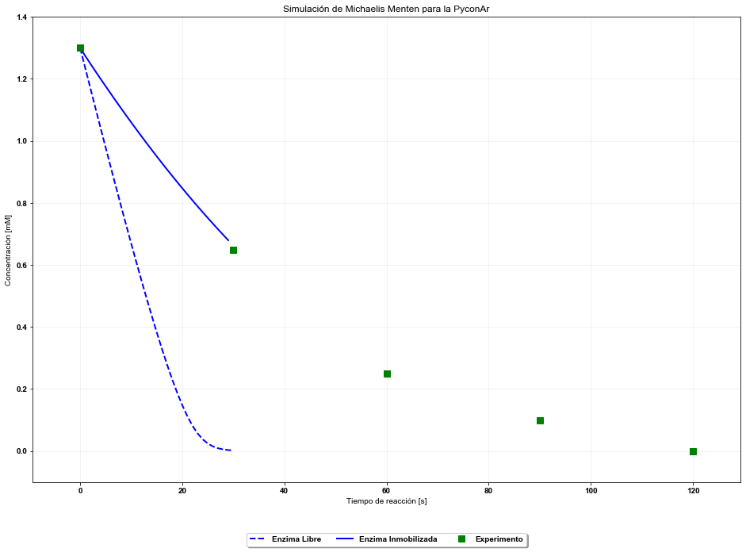

```python
SIM1.plot(figsize=(16,12))
```

##### Coding as a Service: librería pypsdier, aprendizajes y metodología

### Ejemplo pypsdier

¿Y la reproducibilidad?

Una simulación realizada almacena todas las características con las cuales se generó.

```python
import pypsdier
SIM2 = pypsdier.SimulationInterface()
SIM2.load("pycon_colab_example.rde") # load instead of new
```

```
Loaded a simulation from /Users/sebastiandres/Desktop/Personales/github_repos/charlas/2020_11_XX_pycon_ar_pypsdier/pycon_colab_example.rde
```

```python
SIM2.status()
```

```
System configuration:
    environment: google_colab
    python version: 3.6.9
    GenericSimulationLibrary version: 1.1.0
    numpy version: 1.18.5
    scipy version: 1.4.1
    xlwt version: 1.3.0
    matplotlib version: 3.2.2
    dill version: 0.3.2
Inputs:
    SimulationTime: 120.0
    SavingTimeStep: 1.0
    CatalystVolume: 0.5
    BulkVolume: 100.0
    Names: ('Substrat',)
    InitialConcentrations: (1.3,)
    EffectiveDiffusionCoefficients: (5.3e-10,)
    CatalystParticleRadius: [4e-05, 6e-05, 8e-05]
    CatalystParticleRadiusFrequency: [0.3, 0.5, 0.2]
    ReactionFunction: <function MichaelisMenten at 0x134d50dd0>
    ReactionParameters: (41, 0.13)
    CatalystEnzymeConcentration: 0.35
Plot Options:
    title: Simulación de Michaelis Menten para la PyconAr
    label_x: Tiempo de reacción [s]
    label_y: Concentración [mM]
    ode_kwargs: {'label': 'ode', 'color': 'black', 'marker': '', 'markersize': 6, 'linestyle': 'dashed', 'linewidth': 2}
    pde_kwargs: {'label': 'pde', 'color': 'black', 'marker': '', 'markersize': 6, 'linestyle': 'solid', 'linewidth': 2}
    data_kwargs: {'label': 'exp', 'color': 'red', 'marker': 's', 'markersize': 6, 'linestyle': 'none', 'linewidth': 2}
    data_x: [0.0, 30, 60, 90, 120]
    data_y: [1.3, 0.65, 0.25, 0.1, 0.0]
Simulations:
    ODE: yes
    PDE: yes
```

##### Coding as a Service: librería pypsdier, aprendizajes y metodología

### Ejemplo pypsdier

Podemos cargar una simulación realizada previamente y analizarla (sin necesidad de volver a realizar la simulación).

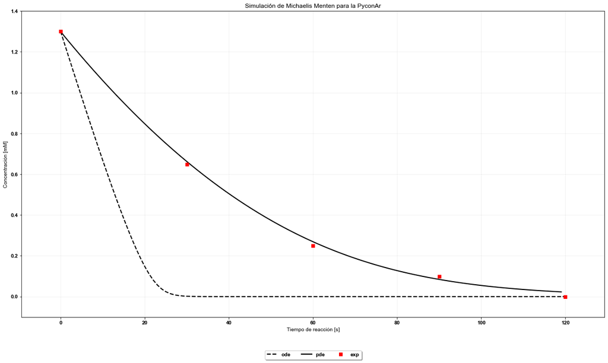

```python
SIM2.plot(figsize=(20,12))
```

##### Coding as a Service: librería pypsdier, aprendizajes y metodología

### Framework Propuesto

La librería pypsdier es específica al problema de reacción-difusión para reactores de enzima inmobilizada, con flexibilidad para diferentes modelos de reacción y condiciones de operación.

Sin embargo, se propone un framework de trabajo con las funcionalidades mínimas: **GenericSimulationLibrary**

Disponible en https://github.com/sebastiandres/GenericSimulationLibrary:

- En `simulation_interface.py` actualizar los métodos: new, load, simulate, save, plot, export.
- En `docs/source/*.rst` actualizar la documentación.

##### Coding as a Service: librería pypsdier, aprendizajes y metodología

### Conclusión

Todo lo anterior no es muy distinto a lo que se hace en una librería "formal".

**Aprendizaje**:

Puedes usar las mismas herramientas e ideas, aunque tu equipo y proyecto sea más pequeño e informal, porque simplifican y mejoran la colaboración.

- git + github/bitbucket.
- readthedocs
- pypi
- google colab/mybinder
- Interface OO

# Coding as a Service: Librería pypsdier, aprendizajes y metodología.

## Sebastián Flores

### Pycon Argentina 2020

Encuesta:  
https://bit.ly/354jhrQ

[figure not shown]